# Unsupervised Learning

Rohit

4/20/2020

## 1. Packages Required

The below packages were used to complete the analysis.

```r
library (tidyverse)
library (ggfortify)
library (qdapTools)
library (caret)
```

```r
library (tidyr)
library (corrplot)
library (ggpubr)
library(ggplot2)
library(PerformanceAnalytics)
```

## 2. Initial Data Exploration

### 2.1 Reading in files

The data set was imported into R studio using the below code

```r
data <- read.csv("players_20.csv", stringsAsFactors = FALSE)

attach(data)
```

### 2.2 Check the structure of data set

Before we begin exploring the data, we use str() & head()function to see the structure and dimensions of the dataset.

```r
head (data) #display head of the data
```

```
##   sofifa_id
## 1    158023
## 2     20801
## 3    190871
## 4    200389
## 5    183277
## 6    192985
##                                                              player_url
## 1               https://sofifa.com/player/158023/lionel-messi/20/159586
## 2 https://sofifa.com/player/20801/c-ronaldo-dos-santos-aveiro/20/159586
## 3  https://sofifa.com/player/190871/neymar-da-silva-santos-jr/20/159586
## 4                  https://sofifa.com/player/200389/jan-oblak/20/159586
## 5                https://sofifa.com/player/183277/eden-hazard/20/159586
## 6            https://sofifa.com/player/192985/kevin-de-bruyne/20/159586
##          short_name                           long_name age        dob
```

[output cut: 167 more lines]

```r
str(data)
```

```
## 'data.frame':    18278 obs. of  104 variables:
##  $ sofifa_id                 : int  158023 20801 190871 200389 183277 192985 192448 203376 177003 209331 ...
##  $ player_url                : chr  "https://sofifa.com/player/158023/lionel-messi/20/159586" "https://sofifa.com/player/20801/c-ronaldo-dos-santos-aveiro/20/159586" "https://sofifa.com/player/190871/neymar-da-silva-santos-jr/20/159586" "https://sofifa.com/player/200389/jan-oblak/20/159586" ...
##  $ short_name                : chr  "L. Messi" "Cristiano Ronaldo" "Neymar Jr" "J. Oblak" ...
##  $ long_name                 : chr  "Lionel AndrÃ©s Messi Cuccittini" "Cristiano Ronaldo dos Santos Aveiro" "Neymar da Silva Santos Junior" "Jan Oblak" ...
##  $ age                       : int  32 34 27 26 28 28 27 27 33 27 ...
##  $ dob                       : chr  "1987-06-24" "1985-02-05" "1992-02-05" "1993-01-07" ...
##  $ height_cm                 : int  170 187 175 188 175 181 187 193 172 175 ...
##  $ weight_kg                 : int  72 83 68 87 74 70 85 92 66 71 ...
##  $ nationality               : chr  "Argentina" "Portugal" "Brazil" "Slovenia" ...
##  $ club                      : chr  "FC Barcelona" "Juventus" "Paris Saint-Germain" "AtlÃ©tico Madrid" ...
##  $ overall                   : int  94 93 92 91 91 91 90 90 90 90 ...
##  $ potential                 : int  94 93 92 93 91 91 93 91 90 90 ...
##  $ value_eur                 : int  95500000 58500000 105500000 77500000 90000000 90000000 67500000 78000000 45000000 80500000 ...
##  $ wage_eur                  : int  565000 405000 290000 125000 470000 370000 250000 200000 340000 240000 ...
```

[output cut: 86 more lines]

### 2.3 Deep Dive into Data

### 2.3.1 Plotting replationships using Simple Plot

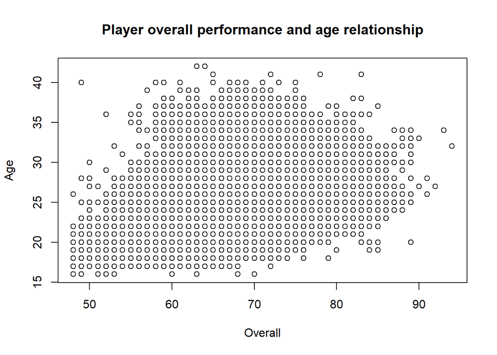

```r
plot (overall, age, xlab = "Overall", ylab = "Age", main = "Player overall performance and age relationship") #overall performance vs the age
```

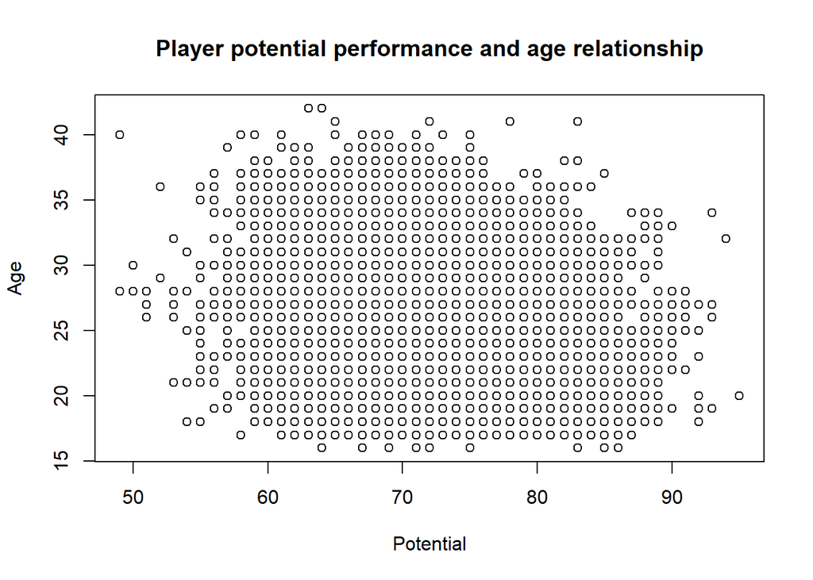

```r
plot (potential, age, xlab = "Potential", ylab = "Age", main = "Player potential performance and age relationship") #potentiall performance vs the age
```

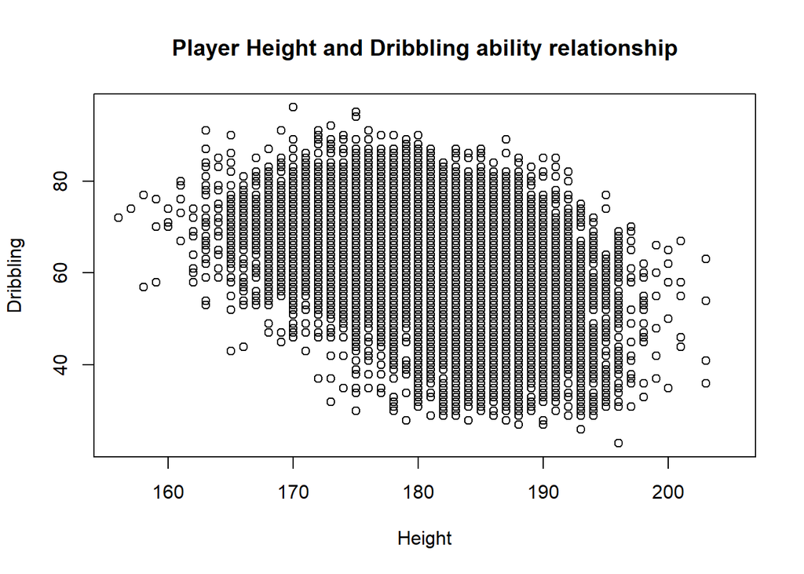

```r
plot (height_cm, dribbling, xlab = "Height", ylab = "Dribbling", main = "Player Height and Dribbling ability relationship") #Height in cm vs Dribbling ability
```

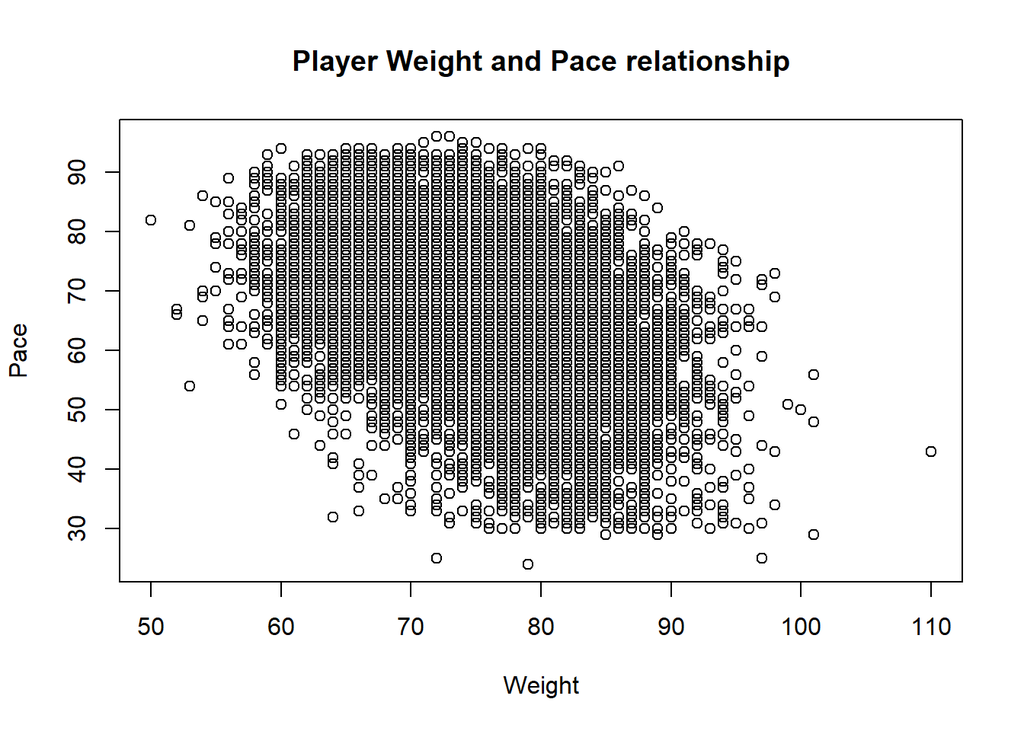

```r
plot (weight_kg, pace, xlab = "Weight", ylab = "Pace", main = "Player Weight and Pace relationship") #Weight in  kg vs Pace
```

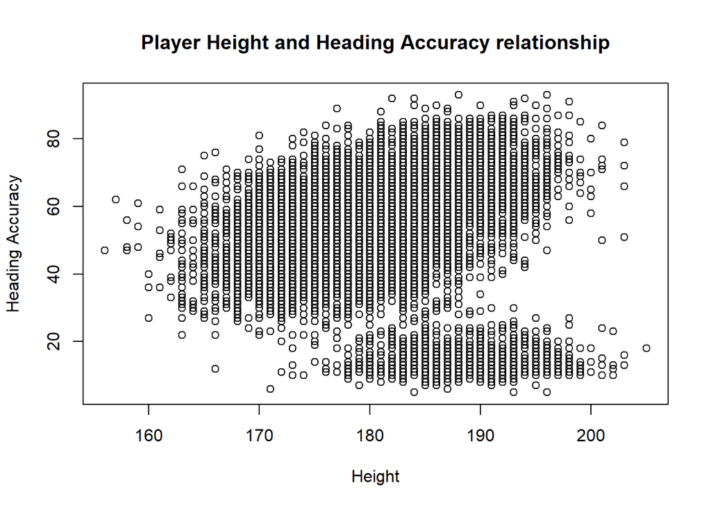

```r
plot (height_cm, attacking_heading_accuracy, xlab = "Height", ylab = "Heading Accuracy", main = "Player Height and Heading Accuracy relationship") #Height in cm vs Heading Accuracy
```

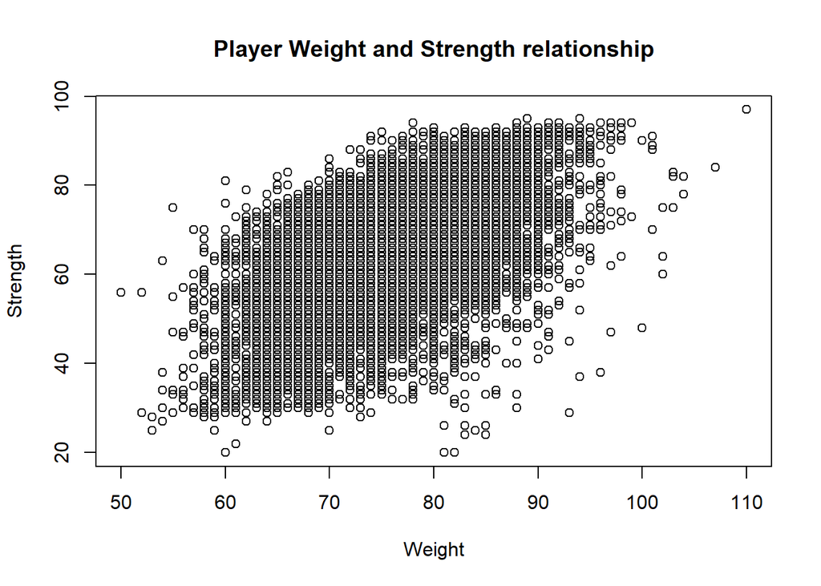

```r
plot (weight_kg, power_strength, xlab = "Weight", ylab = "Strength", main = "Player Weight and Strength relationship") #Weight in  kg vs Strength
```

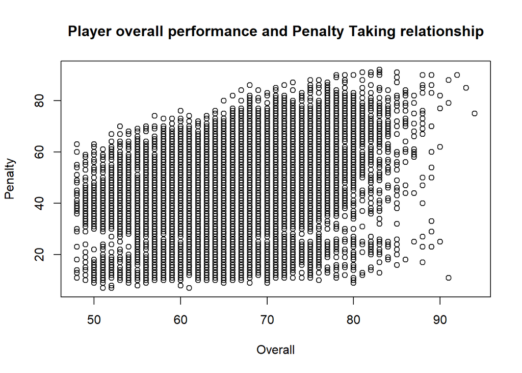

```r
plot (overall, mentality_penalties, xlab = "Overall", ylab = "Penalty", main = "Player overall performance and Penalty Taking relationship") #overall performance vs penalty
```

Observations: From plots above we can notice that players older 25 rarely have overall performance of below 53. Height has negative correlation with Dribbling ability Weight has negative correlation with pace Height has positive correlation with Heading Accuracy Weight has positive correlation with Physical Strength

### 2.3.2 Players according to position

```r
print ("Players position")
```

```
## [1] "Players position"
```

```r
head (player_positions)
```

```
## [1] "RW, CF, ST" "ST, LW"     "LW, CAM"    "GK"         "LW, CF"
## [6] "CAM, CM"
```

Sometimes same player takes over several positions, sometimes only one like a goal keeper. Also notice that names of positions separated by comma and space if several are present. What we can do here is to display for each player it’s relative relation to a position. This can be accomplished in few steps. We remove white spaces from all cells in player_positions column. We separate any string in the cell by comma if there any comma present. We transform column into a matrix N x n where N - number of rows in the data (total number of rows present in the table) and n is the total number of unique attributes found in the column. In our case we have 15 attributes, so the table will be N x 15.

```r
player_positions <- gsub('\\s+', '',player_positions)#remove white spaces from specified columns
players_role <- mtabulate(strsplit(player_positions, ",")) #one hot encode player position

print ("Number of entries (rows) and number of (columns) of the matrix")
```

```
## [1] "Number of entries (rows) and number of (columns) of the matrix"
```

```r
dim (players_role)
```

```
## [1] 18278    15
```

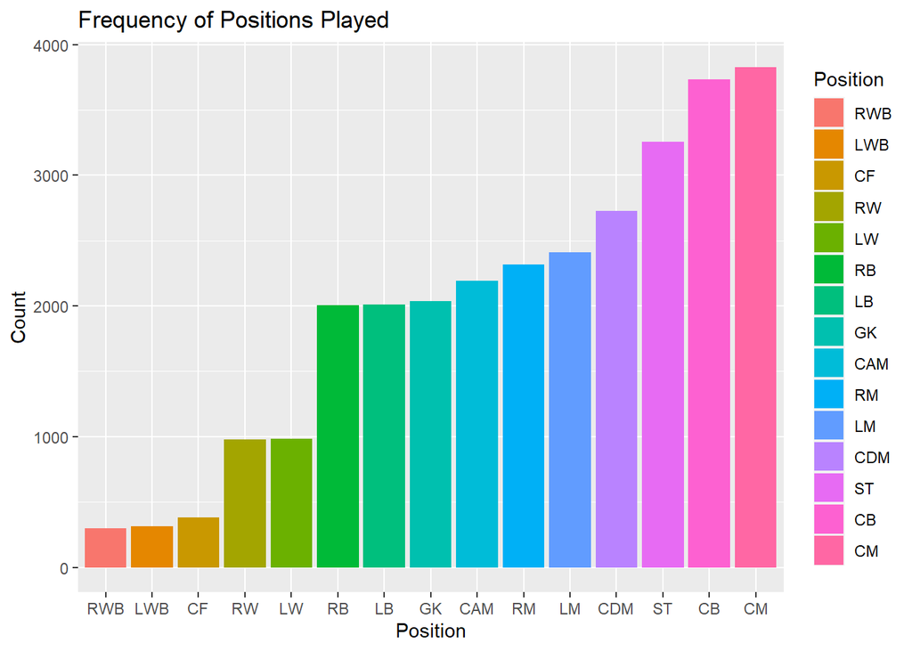

```r
role_frequency <- t(sort(apply (players_role, 2, sum))) #count number of players position appearing
role_frequency <- gather (data.frame(role_frequency), Position, Count) #transfer data into format for ggplot
role_frequency$Position <- reorder(role_frequency$Position, role_frequency$Count)#reorder position by ascending count
ggplot(role_frequency, aes(x=Position, y = Count, fill = Position)) + geom_bar(stat = "identity") + ggtitle("Frequency of Positions Played")#barplot of players position frequency
```

Observation: It is clear that right and left back wingers were the least popular among players while back mid and forward center positions were the most popular positions.

To see correlation between values in the table (players_role) we can compute correlation between them by applying function cor. It requires only numeric columns, make sure you do not have any rows with string inside.

We can plot corrplot using corrplot function of corrplot package. One can specify various arguments of a function. corrplot:: specifies the namespace of a package. It can be helpful when two packages have different function but share same function name.

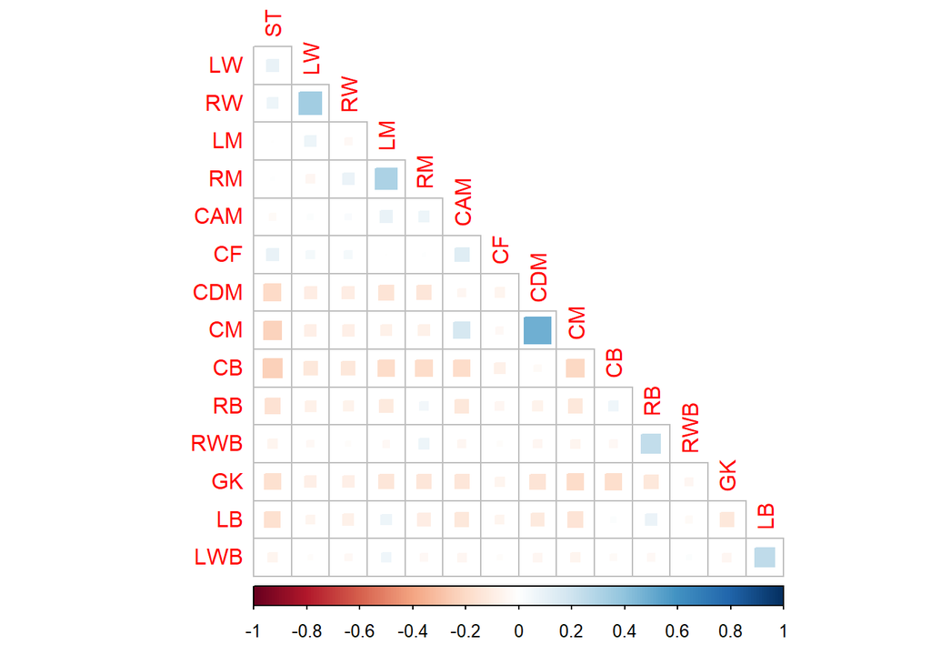

```r
role_cor <- cor(players_role) #correlation between players role
corrplot::corrplot(role_cor, hclust.method = "ward.D", order = "hclust", method = "square",diag = F, type = "lower" ) #correlation plot
```

It seems that central forward position (ST) is negatively correlated with (CM - Central middle, CDM - Central defense middle, CB - Central backfielder, RB - right backfielder) a little less with GK - goal keeper and LB - left backfielder. Clearly players playing in the forward position rarely play in the defense

### 2.4 Data Cleaning - Splitting into two groups

If we divide the whole dataset into two groups - Outfield players and Goalkeepers then there would be no Null values as we can assign attributes relevant to a GK and outfield players.

This will also help us to align our model to our problem statement

```r
data_gk <- subset(x=data, subset= player_positions == "GK", select = c(sofifa_id,short_name,age,height_cm,weight_kg,overall,potential,value_eur,wage_eur,player_positions,international_reputation,weak_foot,skill_moves,gk_diving,gk_handling,gk_kicking,gk_reflexes,gk_speed,gk_positioning,attacking_crossing,attacking_finishing,attacking_heading_accuracy,attacking_short_passing,attacking_volleys,skill_dribbling,skill_curve,skill_fk_accuracy,skill_long_passing,skill_ball_control,movement_acceleration,movement_sprint_speed,movement_agility,movement_reactions,movement_balance,power_shot_power,power_jumping,power_stamina,power_strength,power_long_shots,mentality_aggression,mentality_interceptions,mentality_positioning,mentality_vision,mentality_penalties,mentality_composure,defending_marking,defending_standing_tackle,defending_sliding_tackle,goalkeeping_diving,goalkeeping_handling,goalkeeping_kicking,goalkeeping_positioning,goalkeeping_reflexes))
head(data_gk)
```

```
##    sofifa_id    short_name age height_cm weight_kg overall potential
## 4     200389      J. Oblak  26       188        87      91        93
## 7     192448 M. ter Stegen  27       187        85      90        93
## 14    212831       Alisson  26       191        91      89        91
## 15    193080        De Gea  28       192        82      89        90
## 26    210257       Ederson  25       188        86      88        91
## 29    192119   T. Courtois  27       199        96      88        89
##    value_eur wage_eur player_positions international_reputation weak_foot
## 4   77500000   125000               GK                        3         3
## 7   67500000   250000               GK                        3         4
## 14  58000000   155000               GK                        3         3
## 15  56000000   205000               GK                        4         3
## 26  54500000   185000               GK                        2         3
## 29  48000000   235000               GK                        4         2
##    skill_moves gk_diving gk_handling gk_kicking gk_reflexes gk_speed
```

[output cut: 83 more lines]

```r
dim(data_gk)
```

```
## [1] 2036   53
```

```r
data_outfield <- subset(x=data, subset= player_positions != "GK", select = c(sofifa_id,short_name,age,height_cm,weight_kg,overall,potential,value_eur,wage_eur,player_positions,international_reputation,weak_foot,skill_moves,pace,shooting,passing,dribbling,defending,physic,attacking_crossing,attacking_finishing,attacking_heading_accuracy,attacking_short_passing,attacking_volleys,skill_dribbling,skill_curve,skill_fk_accuracy,skill_long_passing,skill_ball_control,movement_acceleration,movement_sprint_speed,movement_agility,movement_reactions,movement_balance,power_shot_power,power_jumping,power_stamina,power_strength,power_long_shots,mentality_aggression,mentality_interceptions,mentality_positioning,mentality_vision,mentality_penalties,mentality_composure,defending_marking,defending_standing_tackle,defending_sliding_tackle,goalkeeping_diving,goalkeeping_handling,goalkeeping_kicking,goalkeeping_positioning,goalkeeping_reflexes))
head(data_outfield)
```

```
##   sofifa_id        short_name age height_cm weight_kg overall potential
## 1    158023          L. Messi  32       170        72      94        94
## 2     20801 Cristiano Ronaldo  34       187        83      93        93
## 3    190871         Neymar Jr  27       175        68      92        92
## 5    183277         E. Hazard  28       175        74      91        91
## 6    192985      K. De Bruyne  28       181        70      91        91
## 8    203376       V. van Dijk  27       193        92      90        91
##   value_eur wage_eur player_positions international_reputation weak_foot
## 1  95500000   565000       RW, CF, ST                        5         4
## 2  58500000   405000           ST, LW                        5         4
## 3 105500000   290000          LW, CAM                        5         5
## 5  90000000   470000           LW, CF                        4         4
## 6  90000000   370000          CAM, CM                        4         5
## 8  78000000   200000               CB                        3         3
##   skill_moves pace shooting passing dribbling defending physic
```

[output cut: 83 more lines]

```r
dim(data_outfield)
```

```
## [1] 16242    53
```

Correrlation of key statistics from GK and Outfield dataframes:

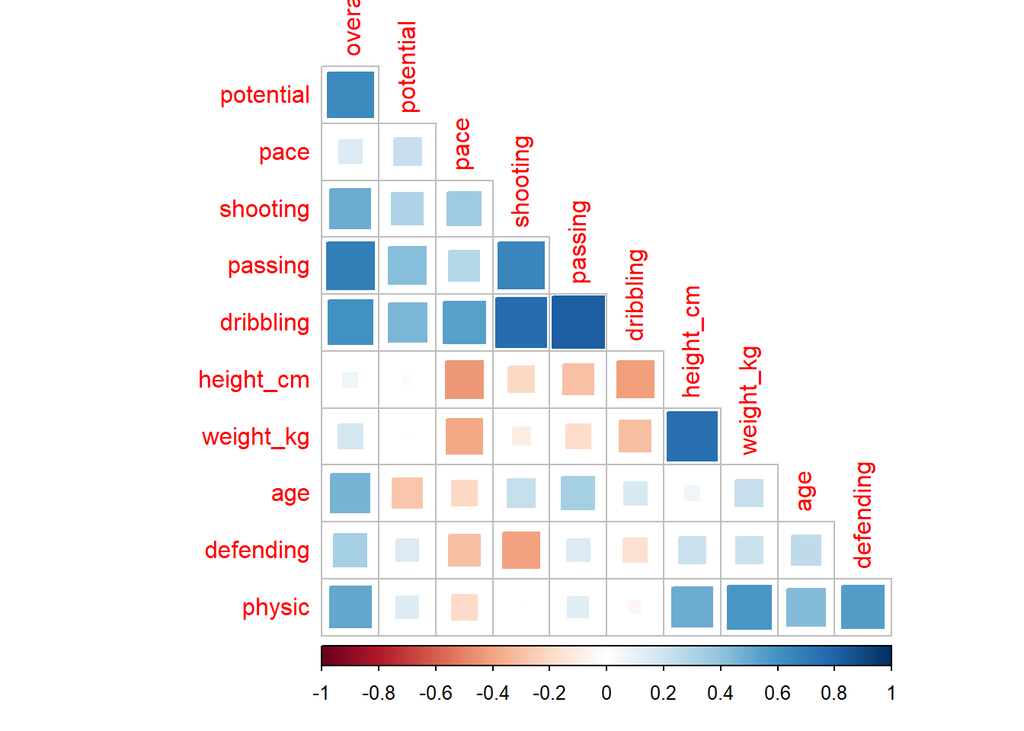

```r
data_outfield_Summary <- subset(x=data_outfield, select = c(age,height_cm,weight_kg, overall, potential,pace,shooting,passing,dribbling,defending,physic))

corr1 <- cor(data_outfield_Summary)
corrplot::corrplot(corr1, hclust.method = "ward.D", order = "hclust", method = "square",diag = F, type = "lower" ) #correlation plot for Outfield Players
```

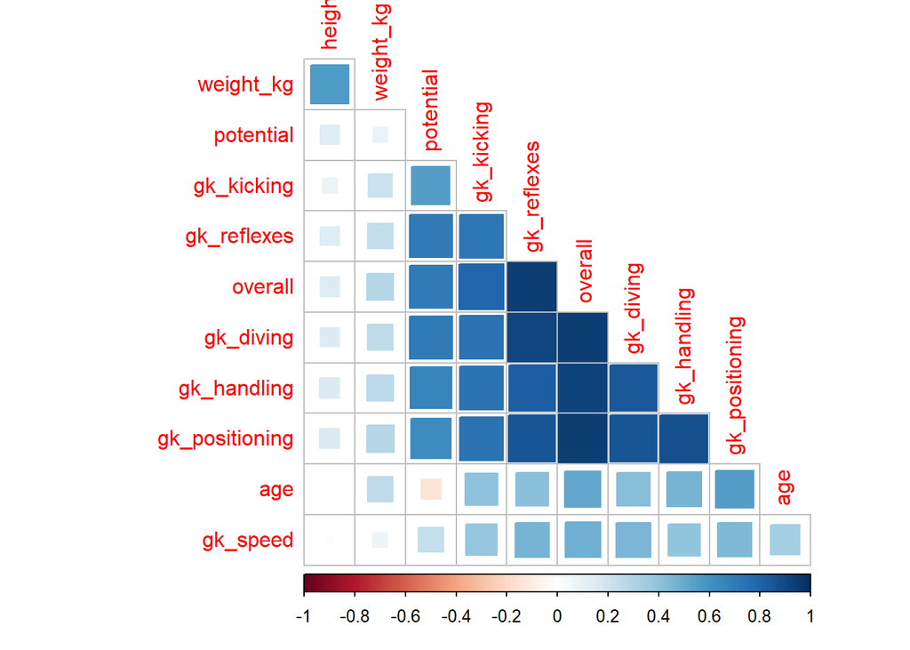

```r
data_gk_Summary <- subset(x=data_gk, select = c(age,height_cm,weight_kg, overall, potential,gk_diving,gk_handling,gk_kicking,gk_reflexes,gk_speed,gk_positioning))

corr2 <- cor(data_gk_Summary)
corrplot::corrplot(corr2, hclust.method = "ward.D", order = "hclust", method = "square",diag = F, type = "lower" ) #correlation plot for GK
```

```r
#chart.Correlation(data_outfield_Summary, histogram=TRUE, pch=19)
```

# EDA NEW

### Checking Null values for Oulfield players and Goalkeeper data separately

```r
count_outfield <- is.na(data_outfield)


sum(count_outfield)
```

```
## [1] 0
```

```r
count_gk <- is.na(data_gk)


sum(count_gk)
```

```
## [1] 0
```

Observations:

After splitting the data into two - Oufield players and Goalkeepers we can see that there are no null values and we get a cleaner data to work on with no abnormalities

### Outfield players according to position

```r
player_positions <- gsub('\\s+', '',data_outfield$player_positions)#remove white spaces from specified columns
players_role <- mtabulate(strsplit(player_positions, ",")) #one hot encode player position

print ("Number of entries (rows) and number of (columns) of the matrix")
```

```
## [1] "Number of entries (rows) and number of (columns) of the matrix"
```

```r
dim (players_role)
```

```
## [1] 16242    14
```

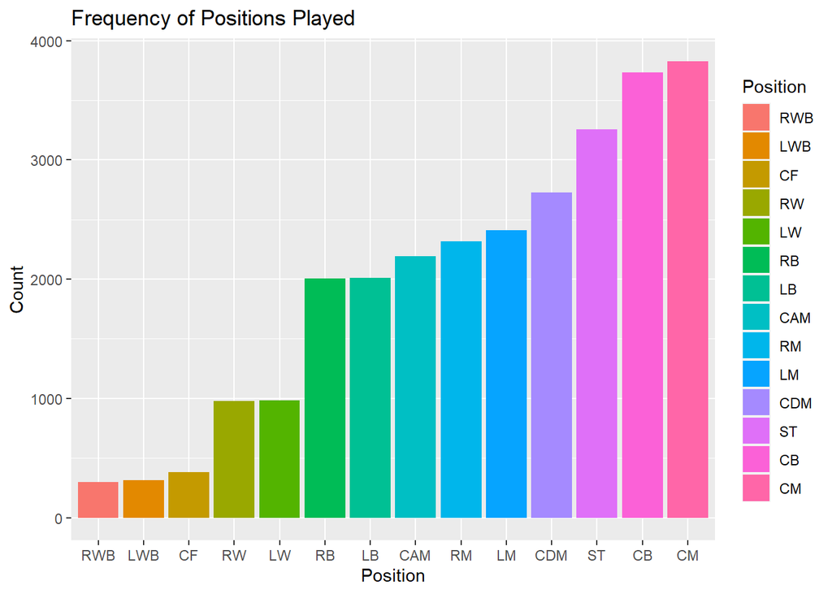

```r
role_frequency <- t(sort(apply (players_role, 2, sum))) #count number of players position appearing
role_frequency <- gather (data.frame(role_frequency), Position, Count) #transfer data into format for ggplot
role_frequency$Position <- reorder(role_frequency$Position, role_frequency$Count)#reorder position by ascending count
ggplot(role_frequency, aes(x=Position, y = Count, fill = Position)) + geom_bar(stat = "identity") + ggtitle("Frequency of Positions Played")#barplot of players position frequency
```

Observation: It is clear that right and left back wingers were the least popular among players while back mid and forward center positions were the most popular positions.

### Correlation amongst outfield players

To see correlation between values in the table (players_role) we can compute correlation between them by applying function cor. It requires only numeric columns, make sure you do not have any rows with string inside.

We can plot corrplot using corrplot function of corrplot package. One can specify various arguments of a function. corrplot:: specifies the namespace of a package. It can be helpful when two packages have different function but share same function name.

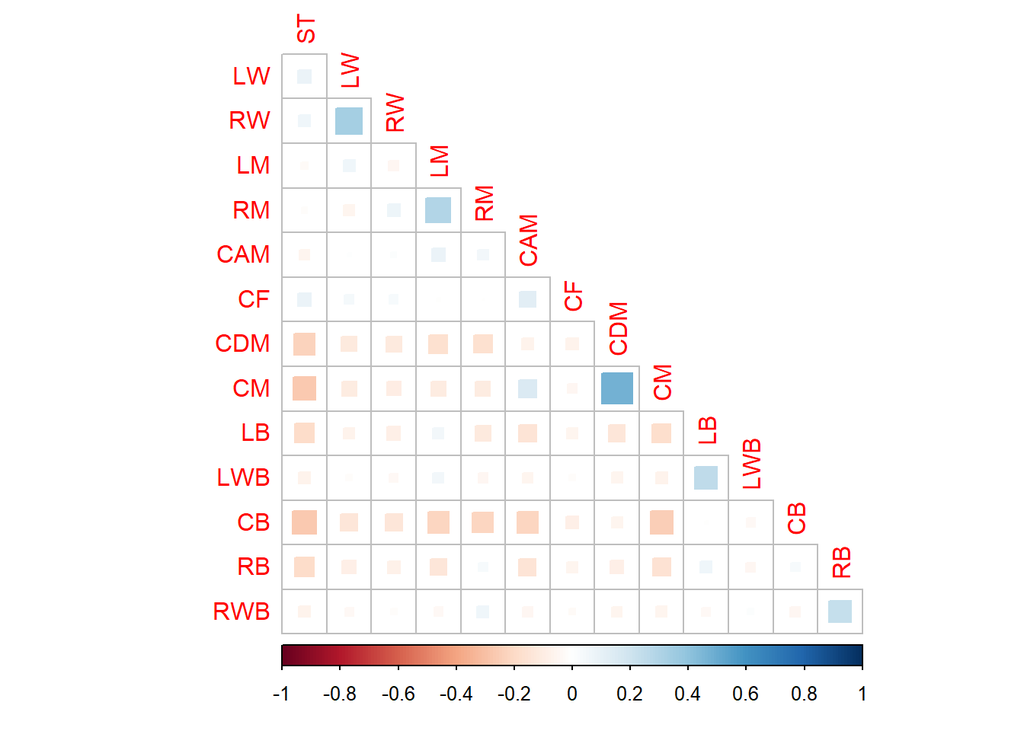

```r
role_cor <- cor(players_role) #correlation between players role
corrplot::corrplot(role_cor, hclust.method = "ward.D", order = "hclust", method = "square",diag = F, type = "lower" ) #correlation plot
```

It seems that central forward position (ST) is negatively correlated with (CM - Central middle, CDM - Central defense middle, CB - Central backfielder, RB - right backfielder) a little less with LB - left backfielder. Clearly players playing in the forward position rarely play in the defense

## Correrlation of key statistics from Outfield dataframes:

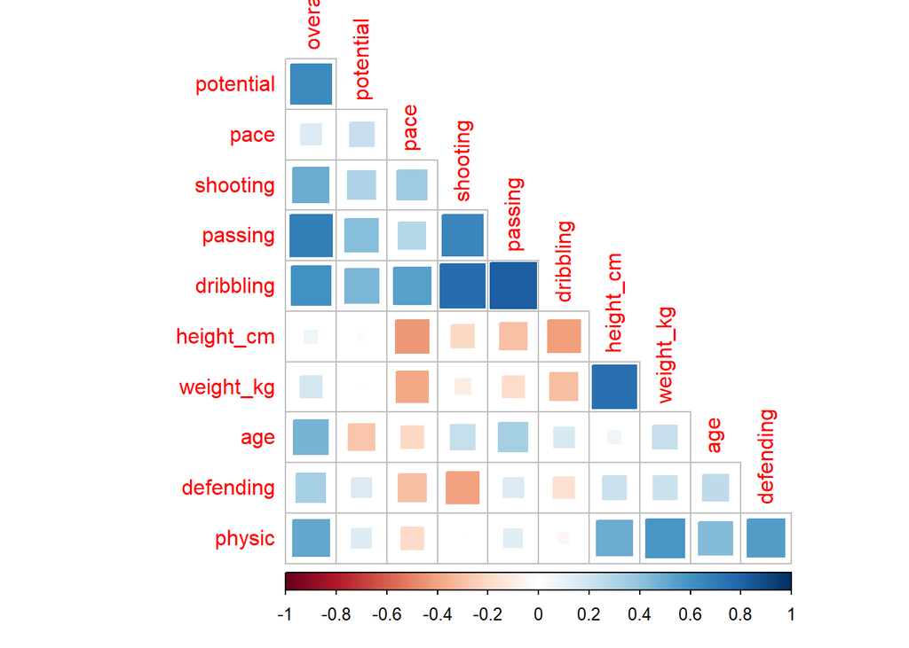

```r
data_outfield_Summary <- subset(x=data_outfield, select = c(age,height_cm,weight_kg, overall, potential,pace,shooting,passing,dribbling,defending,physic))

corr1 <- cor(data_outfield_Summary)
corrplot::corrplot(corr1, hclust.method = "ward.D", order = "hclust", method = "square",diag = F, type = "lower" ) #correlation plot for Outfield Players
```

```r
#chart.Correlation(data_outfield_Summary, histogram=TRUE, pch=19)
```